# #Loan analysis by Alona Sukretna

**Data set:** I choose Loan Data from Prosper (https://s3.amazonaws.com/udacity-hosted-downloads/ud651/prosperLoanData.csv). This data set contains 113,937 loans with 81 variables on each loan, including loan amount, borrower rate (or interest rate), current loan status, borrower income, borrower employment status, borrower credit history, and the latest payment information.

# Univariate Plots Section

**Preliminary exploration of dataset**: There are a lot of NA data in our dataset, but there is reasons why data is empty. For example, different stage of loans, applied methodics and so on. So, we’ll be doing data cleaning if needed during our exploration.

First, let’s explore main parameteres for loans, e.g. amount, term, current status.

### 1. Loan Original Amount

```
##    Min. 1st Qu.  Median    Mean 3rd Qu.    Max.
##    1000    4000    6500    8337   12000   35000
```

We have loans in our data set that starts from $1000 up to $35,000. The average loan amount is $8,337.

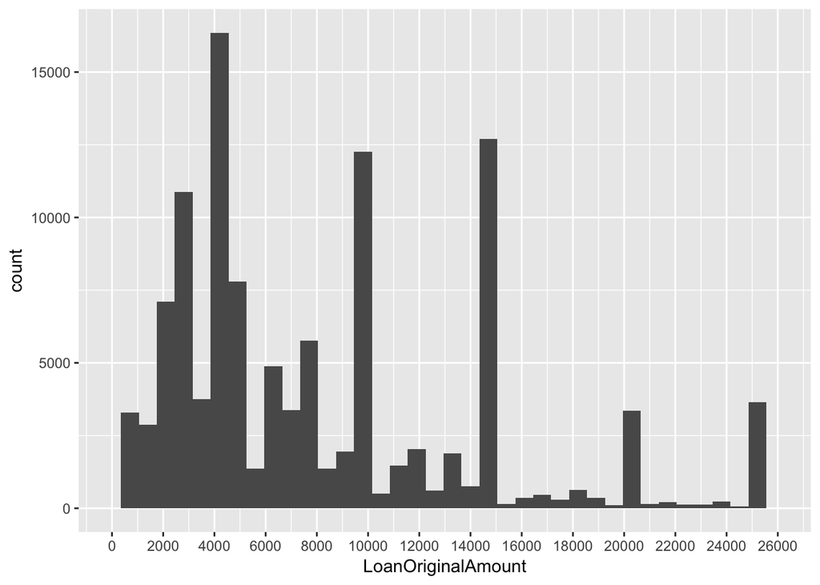

```
##    Min. 1st Qu.  Median    Mean 3rd Qu.    Max.
##    1000    4000    6500    8337   12000   35000
```

We can see that the largest count of loans for $4,000. Also we have a few peak counts for $2,000, $3,000, $5,000, $10,000, $15,000, $20,000, $25,000. Probably, the greateast count of $4000 loans is due to different procedures and requirements for larger amounts. There is a few loans larger $25,000 but for more clear view we can exclude them from our plot. The mean loan amount is $8337.

### 2.Loan Term

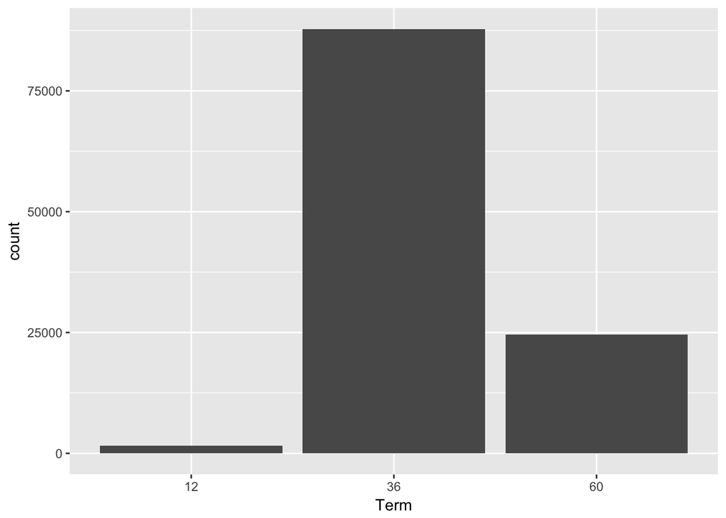

Most loans are for 36 months(3 years), less for 60 months(5 years), and the least for 12 moths.

### 3.Loan Current Status

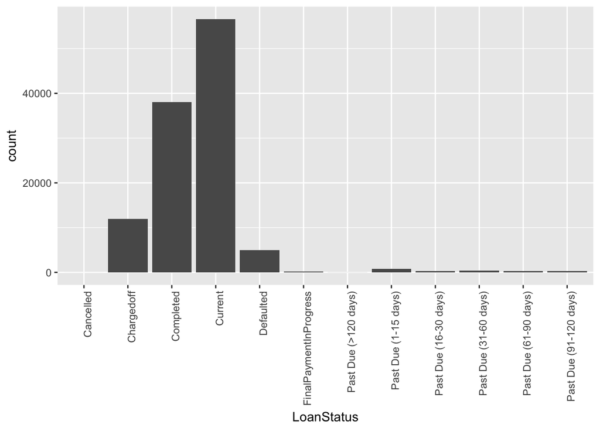

Obviously, the most loans are in Current status. There are a lot of Completed loans in our data set. A big count of loans are Chargeoff (no payments for 6 month, unlikely to be collected) and Defaulted. Past Due loans have own gradation. Tere is small count of such loans but I prefer not exclude them from analysis because they connected with further analyzed parameters.

```
##
##              Cancelled             Chargedoff              Completed
##                      5                  11992                  38074
##                Current              Defaulted FinalPaymentInProgress
##                  56576                   5018                    205
##   Past Due (>120 days)   Past Due (1-15 days)  Past Due (16-30 days)
##                     16                    806                    265
##  Past Due (31-60 days)  Past Due (61-90 days) Past Due (91-120 days)
##                    363                    313                    304
```

### 4. Aim of the loan(Listing Category)

The category of the listing that the borrower selected when posting their listing: 0 - Not Available, 1 - Debt Consolidation, 2 - Home Improvement, 3 - Business, 4 - Personal Loan, 5 - Student Use, 6 - Auto, 7- Other, 8 - Baby&Adoption, 9 - Boat, 10 - Cosmetic Procedure, 11 - Engagement Ring, 12 - Green Loans, 13 - Household Expenses, 14 - Large Purchases, 15 - Medical/Dental, 16 - Motorcycle, 17 - RV, 18 - Taxes, 19 - Vacation, 20 - Wedding Loans.

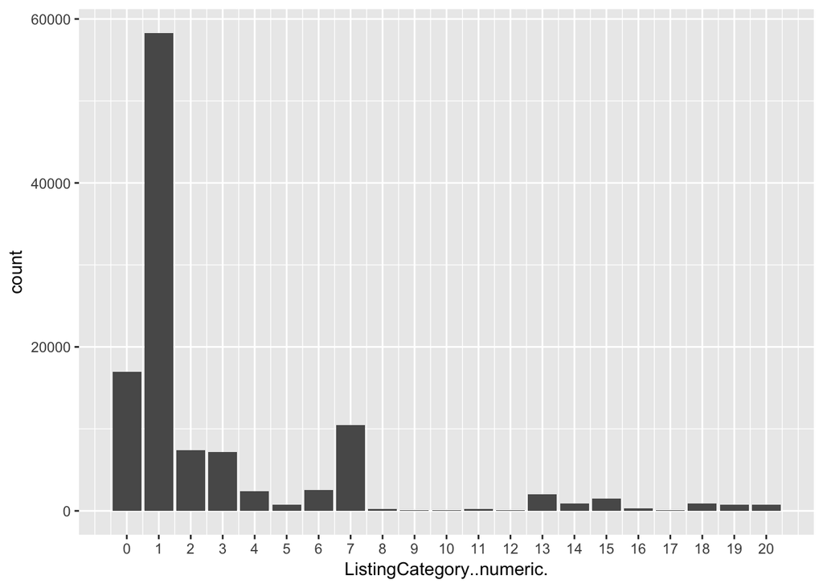

The most loans are for Debt Consolidation. For big count of loans information not available or not in listed categories (‘others’).

### 5.Loan Origination Date

It’s in format “3/3/2014 12:00:00 AM”, we don’t need time for analysis.

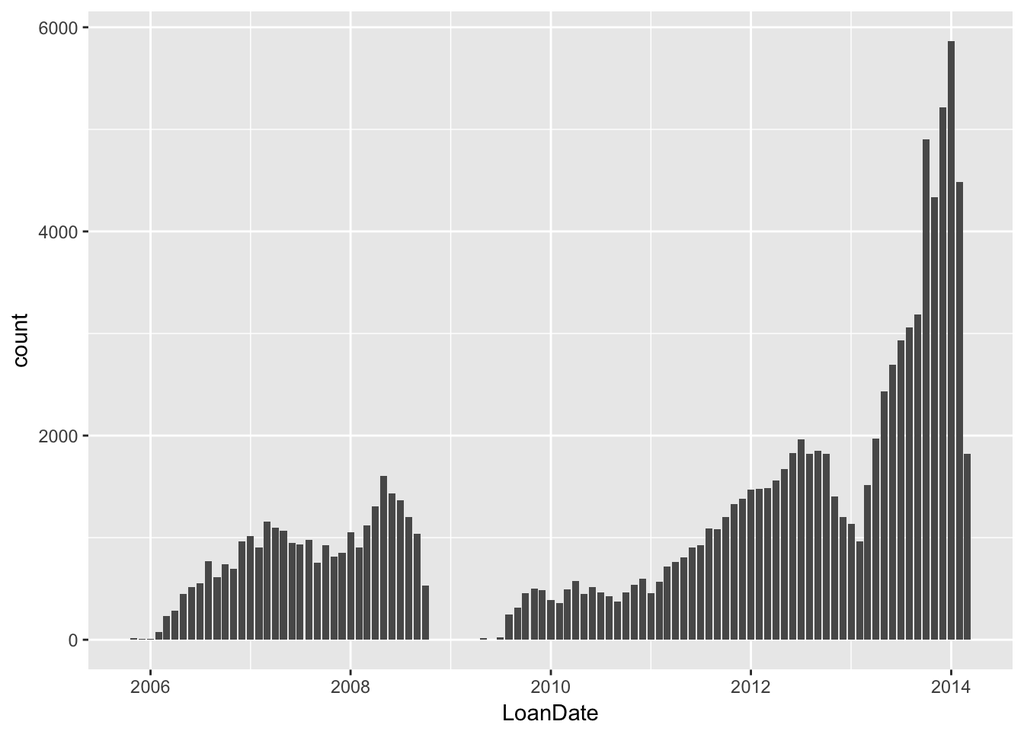

We can see that we have data from the end of 2005 to the 2014. Company loans grows for this period with a few ups and downs and 1 gap around 2009. This gap can be explained that company has changed it’s business model at that time(2008 ‘quiet period’ and 2009 SEC registration according to Wikipedia)

### 6. ProsperRating..numeric.

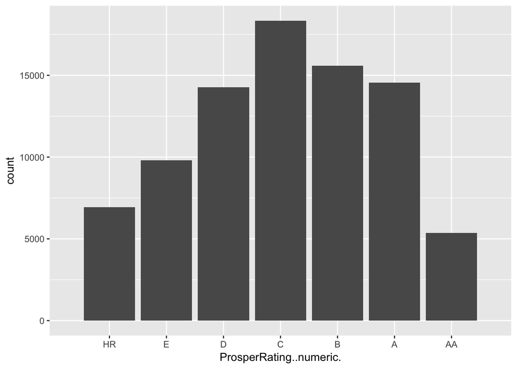

We have most loans with average ProsperRating and less with the highest and lowest ratings.

### 7. CreditScoreRangeLower

We have two indicators of Credit Score:CreditScoreRangeLower and CreditScoreRangeUpper. I plot it together to see the difference.

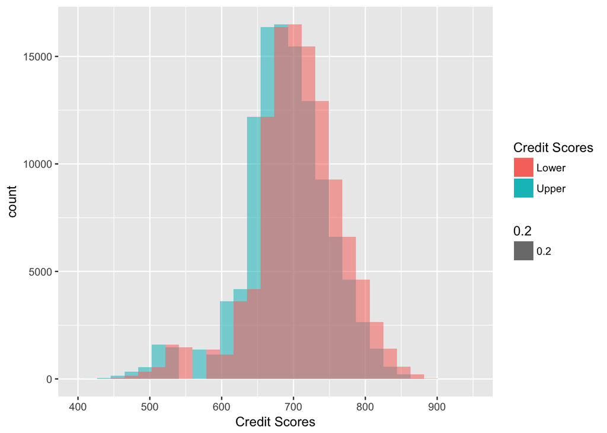

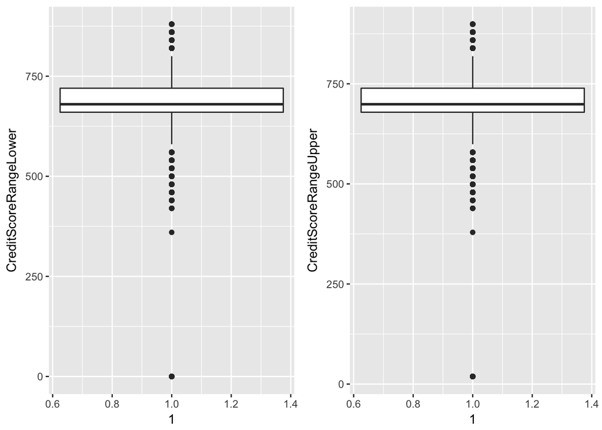

For further analysis we’ll use CreditScoreRangeLower, because it’s a minimum acceptable value that mentioned in Prosper rules. Or alternatively we can create additional value that is average of lower and upper scores.

The plot shows that in average credit scores veries from 640 to 750 and further in most loans. This align with rule that was implemewnted by Prosper in 2009 that minimum Credit Score required to be 640. This also explain small amount of loans with credit score lower 600, that for sure was isuued before 2009 and lead to revision of rules.

### 8. Estimated Loss

Estimated loss is the estimated principal loss on charge-offs. This parameter is applicable for loans originated after July 2009.

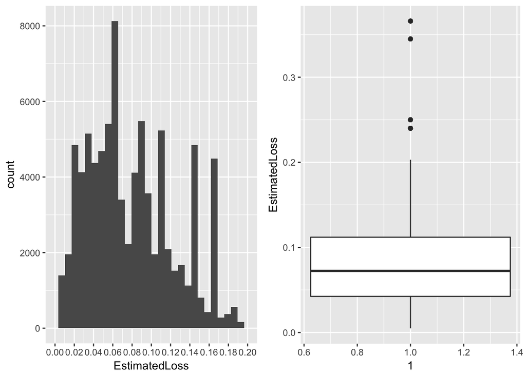

Based on numbers I think it’s not EstimatedLoss amount, but EstimatedLoss Rate (which is not obvious from Variable Definition that comes with data). We have a few loans with EstimatedLoss larger than 0.3, so we can eliminate them to see other data more clear. Also I wanted to see which loans has bigger EstimatedLoss. According to our plot and summary statistics(below) we can see that the biggest number of loans have EstimatedLoss around 0.06.

```
##    Min. 1st Qu.  Median    Mean 3rd Qu.    Max.    NA's
##   0.005   0.042   0.072   0.080   0.112   0.366   29084
```

### 9. Borrower Rate

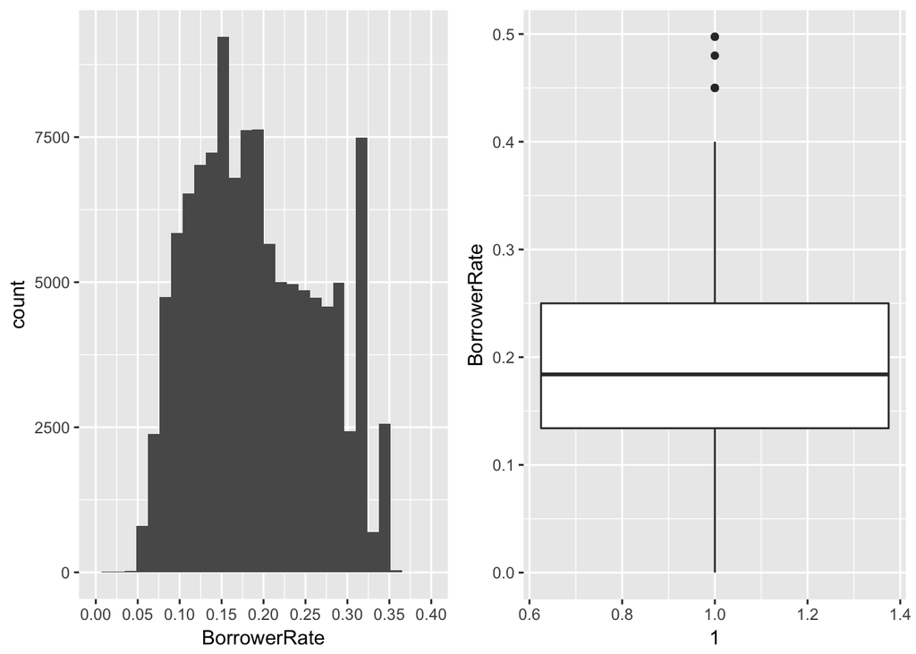

```
##    Min. 1st Qu.  Median    Mean 3rd Qu.    Max.
##  0.0000  0.1340  0.1840  0.1928  0.2500  0.4975
```

Based on plots and summary we can see that average borrower rate is 0.19. Peak at rate 0.31-0.32. I think is for not reliable loans with bad scores and around 0.15 for reliable loans with good scores. There is a few outliers with Borrower Rate more than 0.4. It’s rather exceptions, so we can exclude them from analysis.

### 10. Borrower APR

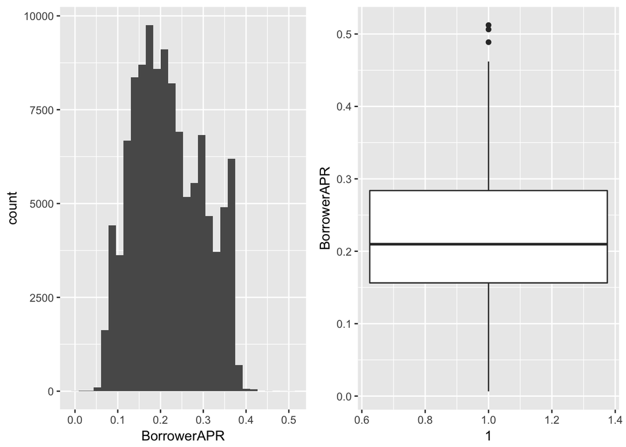

[output not shown]

# Univariate Analysis

**Summarizing data**:

We have big data set with loan data from Prosper from the end of 2005 to 2014. It’s quite representative data set with lot of variables. We don’t need it all for analysis, but better to have more, than less. I’ll make needed changes in the dataset during my investigtion. For example, I created new variable for loan date without time for analysing loan history.

We are interested in loan distribution by year, quality, usage to see all changes. We need to find what are the factors that influence the most on loan quantity and quality.

Also I analyzed a few parameters that I’ll use in further analysis: Prosper Rating, Credit Score, Estimated Loss and Borrower Rate.

Besides analyzed paramateres, also would be interesting to see geography of loan distribution (by BorrowerState), characteristic of people using Prosper (occupation, income), monthly payments.

# Bivariate Plots Section

> **Choosing variables might be interesting to look**: Based on our data set and what we saw in the univariate plots, let’s choose some variables for bivariate analysis. First, we will look on correlation between parameters. The matrix is so big that I preffer not to show it in html.

We can see significant correlation(positive or negative) between BorrowerRate, LenderYield, EstimatedLoss, ProsperRating..numeric, Prosper Score, Credit Score(Lower and Upper) and APR. This is logical because different credit ratings and scores should be comparable to each other. And the worst rating is the bigger will be estimated loss. Also obviously big enough correlation between Loan Amount and Monthly Payment. This matrix is too big. Let’s see this parameters more closely.

### 1. Prosper Rating vs Credit Score.

```
##
##  Pearson's product-moment correlation
##
## data:  mydata$ProsperRating..numeric. and mydata$CreditScoreRangeLower
## t = 191.27, df = 84851, p-value < 2.2e-16
## alternative hypothesis: true correlation is not equal to 0
## 95 percent confidence interval:
##  0.544155 0.553558
## sample estimates:
##       cor
## 0.5488738
```

According to Wikipedia:“Since its SEC registration in 2009, Prosper has provided a proprietary”**Prosper Rating**" for prospective borrowers based on the company’s estimation of that borrower’s “estimated loss rate.” According to the company, that figure is “determined by two scores: (1) the **credit score**, obtained from an official credit reporting agency, and (2) the **Prosper Score**, figured in-house based on the Prosper population.” Prosper Ratings, from lowest-risk to highest-risk, are labeled AA, A, B, C, D, E, and HR (“High Risk”)."

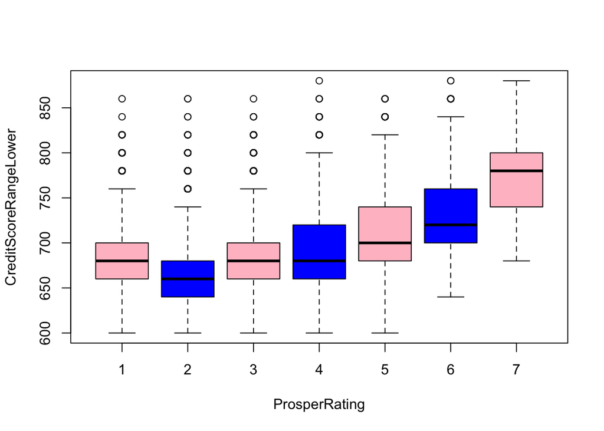

```
## $stats
##      [,1] [,2] [,3] [,4] [,5] [,6] [,7]
## [1,]  600  600  600  600  600  640  680
## [2,]  660  640  660  660  680  700  740
## [3,]  680  660  680  680  700  720  780
## [4,]  700  680  700  720  740  760  800
## [5,]  760  740  760  800  820  840  880
## attr(,"class")
##         1
## "integer"
##
## $n
## [1]  6935  9795 14274 18345 15581 14551  5372
##
## $conf
```

[output cut: 74 more lines]

This boxplot shows the relationship between borrower’s Prosper rating (after July 2009) and CreditScore(Lower). CreditScore is a part of Prosper Rating along with Prosper Score. The higher Rating (7 is the highest) the higher should be Credit Score. Just for rating 1 and 2 we have some exclusions.

Notes: **CreditScoreRangeLower** The lower value representing the range of the borrower’s credit score as provided by a consumer credit rating agency. CreditScoreRangeUpper The upper value representing the range of the borrower’s credit score as provided by a consumer credit rating agency. I used lower level for calculations but we also can create mean CreditScore from Lower and Upper.

**ProsperRating (numeric)** The Prosper Rating assigned at the time the listing was created: 0 - N/A, 1 - HR, 2 - E, 3 - D, 4 - C, 5 - B, 6 - A, 7 - AA. Applicable for loans originated **after July 2009**. ProsperRating (Alpha) The Prosper Rating assigned at the time the listing was created between AA - HR. Applicable for loans originated after July 2009.

Our findings align with information from wikipedia, that " New prospective borrowers were required to have an FICO 8 credit score of at least 640."

### 2. Prosper rating vs Estimated Loss

```
##
##  Pearson's product-moment correlation
##
## data:  mydata$ProsperRating..numeric. and mydata$EstimatedLoss
## t = -1058.9, df = 84851, p-value < 2.2e-16
## alternative hypothesis: true correlation is not equal to 0
## 95 percent confidence interval:
##  -0.9646522 -0.9637054
## sample estimates:
##        cor
## -0.9641819
```

Negative correlation, one variable increases as the other decreases.

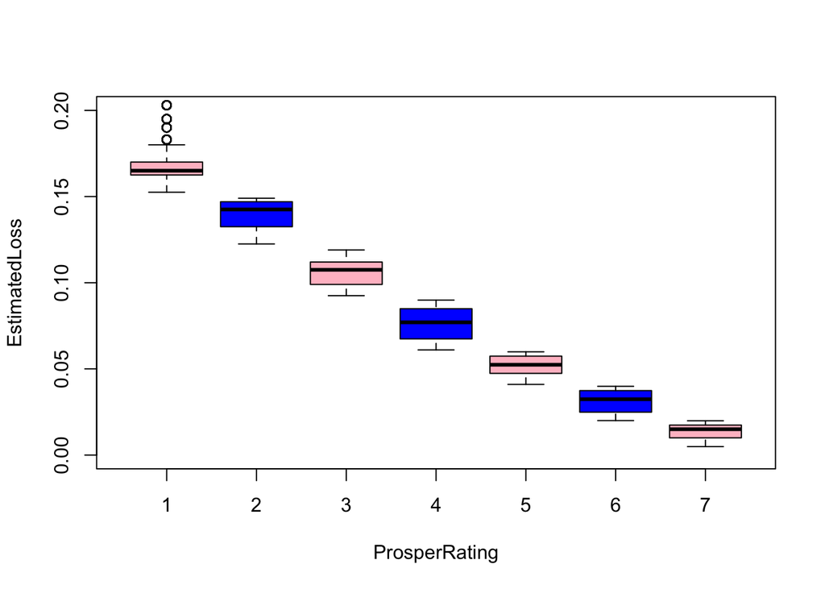

```
## $stats
##        [,1]   [,2]   [,3]   [,4]   [,5]   [,6]   [,7]
## [1,] 0.1525 0.1225 0.0925 0.0610 0.0410 0.0200 0.0049
## [2,] 0.1625 0.1325 0.0990 0.0674 0.0474 0.0249 0.0100
## [3,] 0.1650 0.1425 0.1075 0.0770 0.0524 0.0324 0.0150
## [4,] 0.1700 0.1470 0.1120 0.0849 0.0574 0.0374 0.0174
## [5,] 0.1800 0.1490 0.1190 0.0899 0.0599 0.0399 0.0199
##
## $n
## [1]  6935  9795 14274 18345 15581 14551  5372
##
## $conf
##           [,1]      [,2]      [,3]       [,4]       [,5]       [,6]
## [1,] 0.1648577 0.1422685 0.1073281 0.07679586 0.05227342 0.03223627
## [2,] 0.1651423 0.1427315 0.1076719 0.07720414 0.05252658 0.03256373
```

[output cut: 152 more lines]

For the worst Rating (1) EstimatedLoss will be the most sufficient.

### 3. Prosper Rating vs Loan Amount

```
##
##  Pearson's product-moment correlation
##
## data:  mydata$ProsperRating..numeric. and mydata$LoanOriginalAmount
## t = 138.17, df = 84851, p-value < 2.2e-16
## alternative hypothesis: true correlation is not equal to 0
## 95 percent confidence interval:
##  0.4230486 0.4340341
## sample estimates:
##       cor
## 0.4285572
```

Correlation is not so strong.

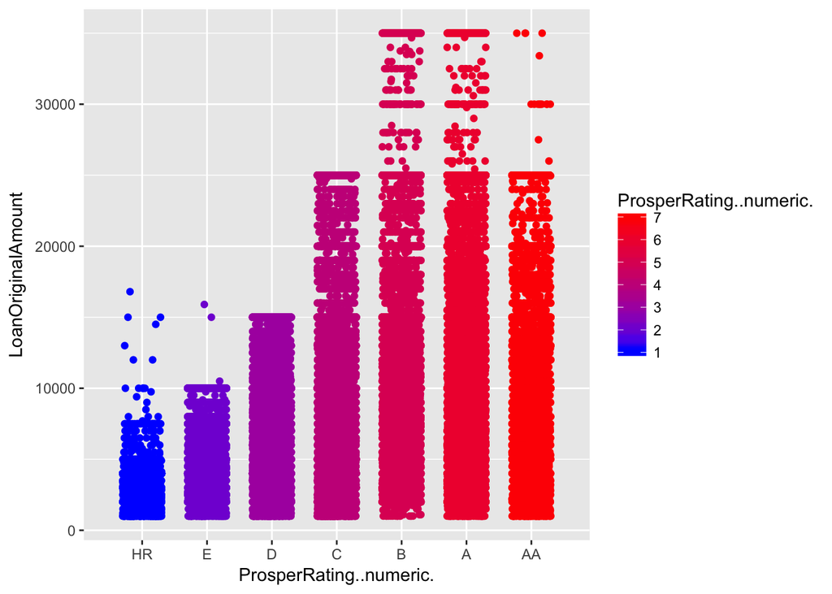

This plot is overplotted so I use a boxplot for the same parameters.

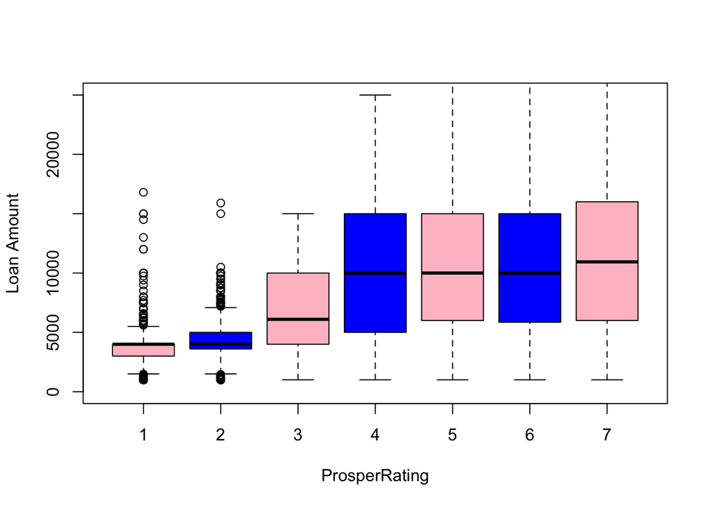

```
## $stats
##      [,1] [,2]  [,3]  [,4]  [,5]  [,6]  [,7]
## [1,] 1500 1500  1000  1000  1000  1000  1000
## [2,] 3000 3600  4000  5000  6000  5850  6000
## [3,] 4000 4000  6100 10000 10000 10000 10940
## [4,] 4000 5000 10000 15000 15000 15000 16000
## [5,] 5500 7086 15000 25000 28500 28450 30000
## attr(,"class")
##         1
## "integer"
##
## $n
## [1]  6935  9795 14274 18345 15581 14551  5372
##
## $conf
```

[output cut: 335 more lines]

I set some limits for the big amount ouliers because it’s rather exceptions. Loans with high ammount of money has higher ratings, that’s mean less risky. High risk loans (HR Rating - 1) are loans for small amounts of money(up tp $10,000).

# Bivariate Analysis

# Multivariate Plots Section

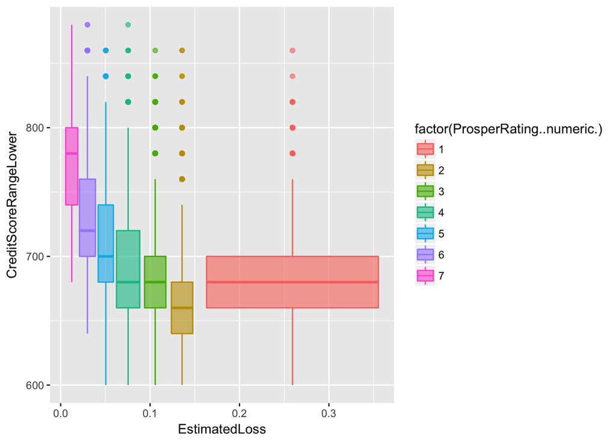

Here we can see again that low Prosper rating(1) leads to bigger Estimatedloss while CreditScore sometimes can be high but have bad Prosper Rating and high loss. This is one of the reasons, I think, that Prosper use their own rating, in which Credit Score is just part of the calculation. just one part of calculation.

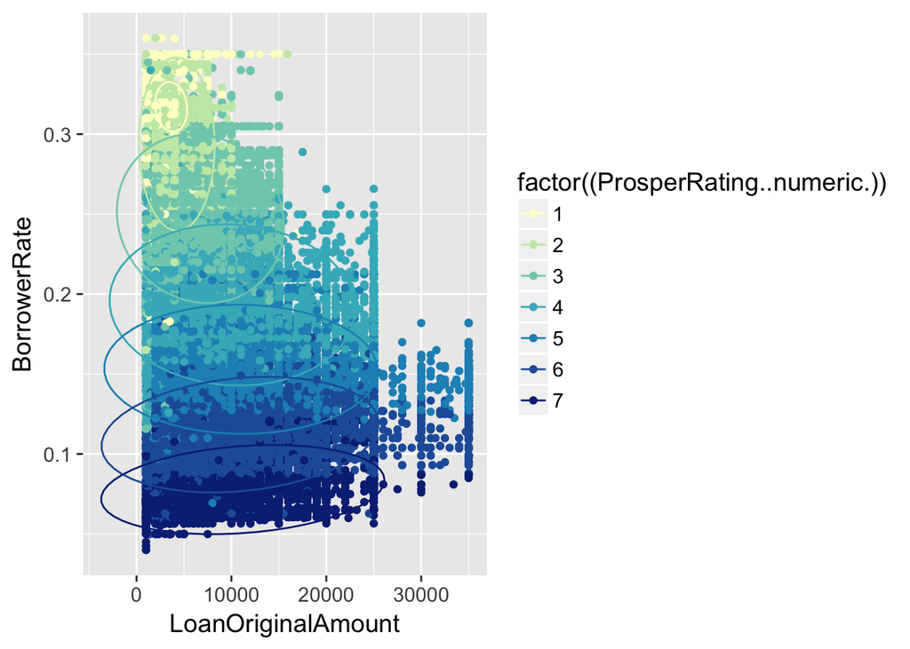

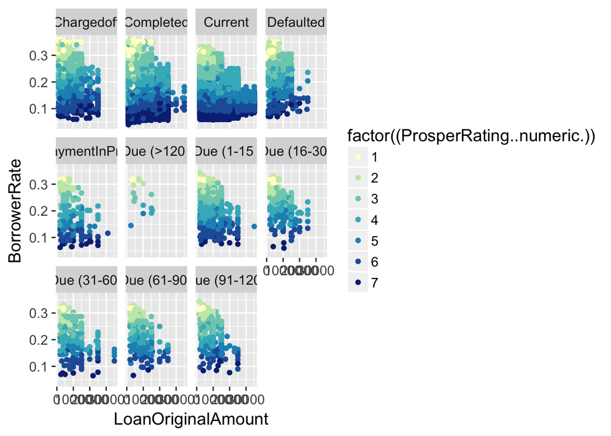

Rate, Rating and Amount don’t depend on Loan Status. With amount it’s obvious, because it fixed. Probably, Borrower Rate and Rating is fixed also from the moment of loan approval. In other practicies borrower’s credit rating can go down for past due.

# Multivariate Analysis

In this part of the investigation we confirm findings from Bivariate analysis and find a few new facts. For example, that Borrower Rate higher for loans with “bad” ratings and low for “good ratings”, but for loans up to $10000 it has all range of rates and ratings. This can testify that small amount of money can be given for different clients on different conditions, even with low Credit Ratings considering other factors (monthly income, homeowner, etc). Also we found that low Prosper rating lead to bigger loss while Credit Score Lower Range sometimes can be pretty high for such loans. This is one of the reasons, I think, that Prosper use their own rating. And we found that there is no dependency between Loan Rate, Prosper Rating and Loan status, what means that they fixed and don’t change when loan is past due.

# Final Plots and Summary

### Plot One

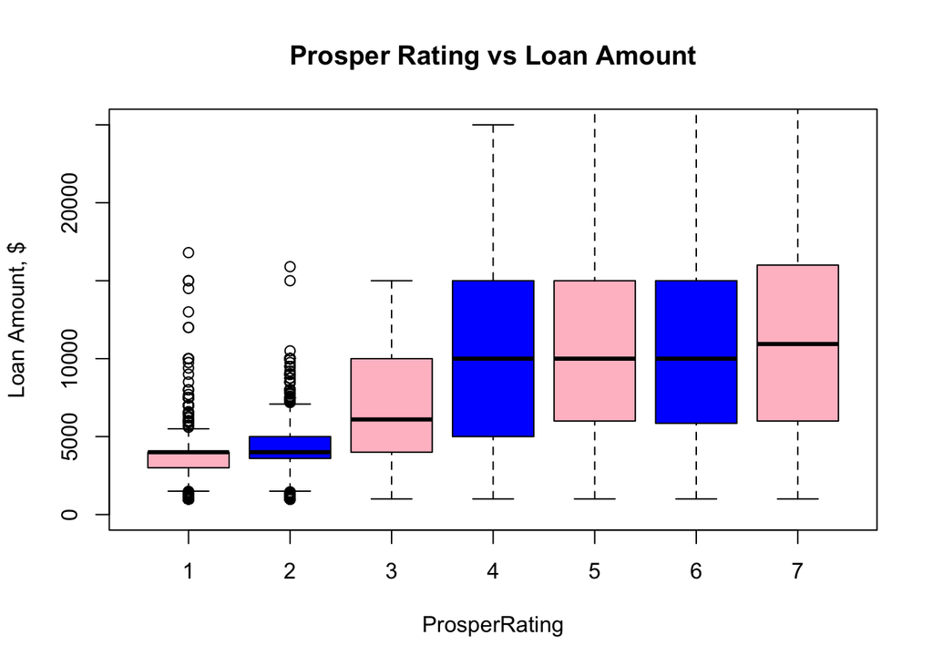

### Description One

This plot shows how Prosper rating connected with Loan Amount. Loans with high ammount of money has higher ratings, that’s mean less risky. High risk loans (HR Rating - 1) are loans for small amounts of money (mostly up to $4,000) with some ouliers.

Also we have the same plots for Credit Score and Estimated Loss.

### Plot Two

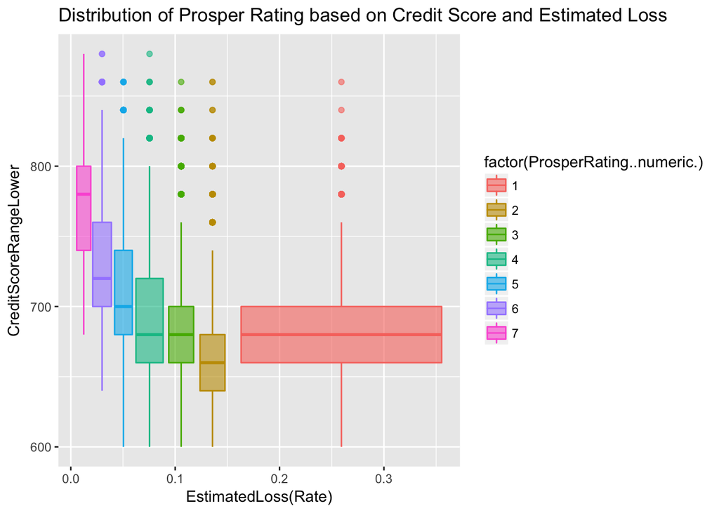

### Description Two

This plot I choose because it shows that Credit Score, that provided by credit rating agencies is not enough to prognose losses, that’s why, probably, it was one of the factor why Prosper choose to use their own rating, which based on Credit Score.

### Plot Three

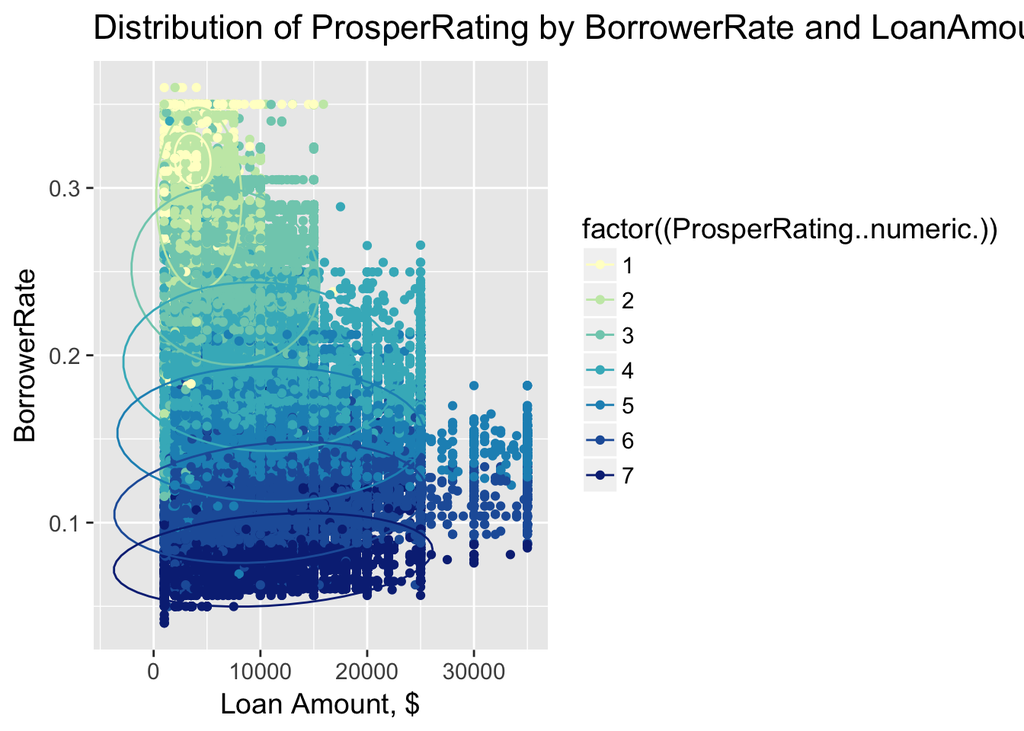

### Description Three

I choose this plot because it shows that big loans only with good ratings and good rates. But as for smaller amounts rule still is, but it can vary sometimes and depend on other factors.

# Reflection

Prosper loan data is pretty big data set with various parameters that represents data from the end of 2005 to the 2014. One of the problems was dertermining which variables to analyze, how to find and deal with missing data and not drifting too far off any one path. I started by understanding the individual variables in the data set, and then I explored in more details Prosper Rating, that was created by this company, and parameteres that closely connected with it(based on correlation and rules of rating’s calculation). Other problem for big data set is overplotting. As I make observations on plots I made conclusion that Prosper decide to use their own rating because ratings from third companies are not enough to prognose losses. It’s also proved by historical data when Prosper had to relaunch after negative return and and implement stricter credit guidelines for borrowers in July 2009. Due to this fact my investigation limited by that fact that Prosper Rating is applicable for loans originated after July 2009. There are a lot more things that we can investigate beased on this dataset.  
For example, we can compare some loan characteristic before and after new rules implementation. We could confirm that Prosper’s loan default rate has been significantly reduced and the percentage of all loans that are 6+ months old, and are 1+ month late, dropped to less than 4% (according to Wikipedia). It would be interesting to build a predictive model that quantifies if the person is going to default on their loan. We could use, for example, a logistic regression.